# NYCFlights: Arrival Delay Logictic Model

Raul

April 29, 2017

## Logsitic and Inverse Logistic Transformation

- Write an R function for the logistic function. The function should accept a `numeric` vector with values `[-Inf,Inf]` and produce a numeric vector in the the range `[0,1]`.
- Plot the logistic function from `[-10,10]`
- Write a R function for the inverse logistic function. The function should accept a `numeric` vector with values `[0,1]` and prodcuce a numeric vector in the range `[-Inf,Inf]`
- Plot the Inverse Logistic function from `[0,1]`

**Hint:** For plotting curves see `?graphics::curve` or `?ggplot2::stat_function`

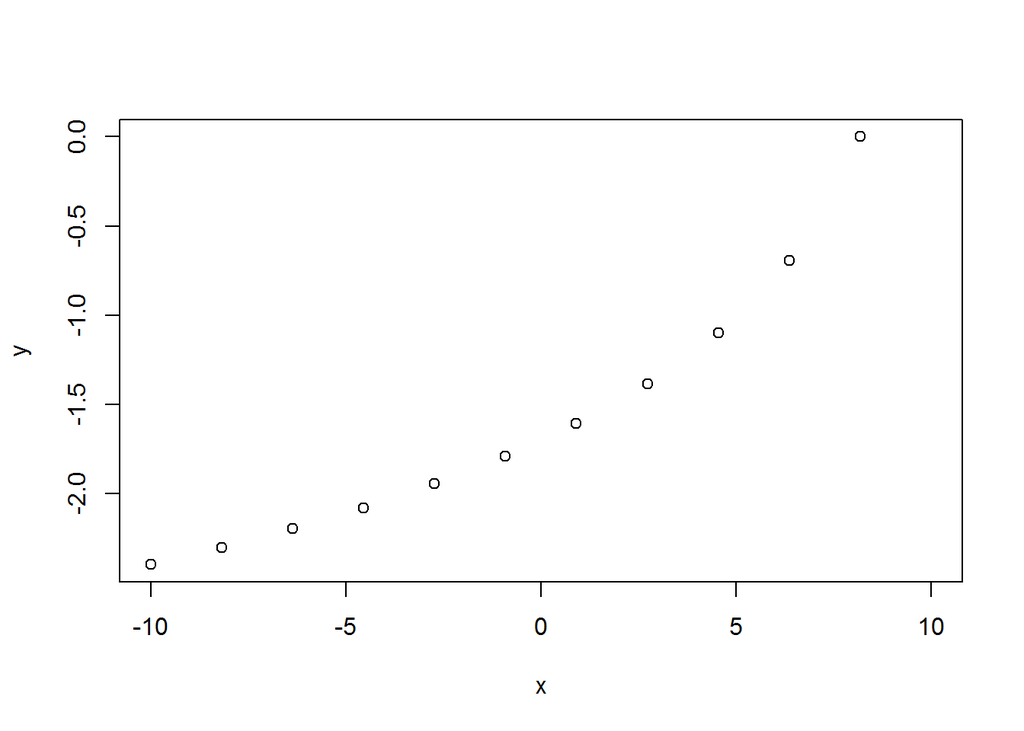

```
##  [1] -2.3978953 -2.3025851 -2.1972246 -2.0794415 -1.9459101 -1.7917595
##  [7] -1.6094379 -1.3862944 -1.0986123 -0.6931472  0.0000000        Inf
## [13]        NaN        NaN        NaN        NaN        NaN        NaN
## [19]        NaN        NaN        NaN
```

```r
logit <- function(x, plot = TRUE) {

    if(!is.numeric(x)) { print("please provide a numeric value or vector") }
    else {
      y <- log(1/(1-x)) #<-apply logistic transformation
      if(plot == TRUE) {qqplot(x,y)} #<-optional visual aid
      return(y)
    }
}

inv.logit <- function(x, plot = TRUE) {

    if(!is.numeric(x)) { print("please provide a numeric value or vector") }
    else {
      y <- exp(x)/(1 + exp(x)) #<-apply inverse logistic transformation
      if(plot == TRUE) {qqplot(min(x):max(x),y)} #<-optional visual aid
      return(y)
    }
}

x <- -10:10
logit(x)
```

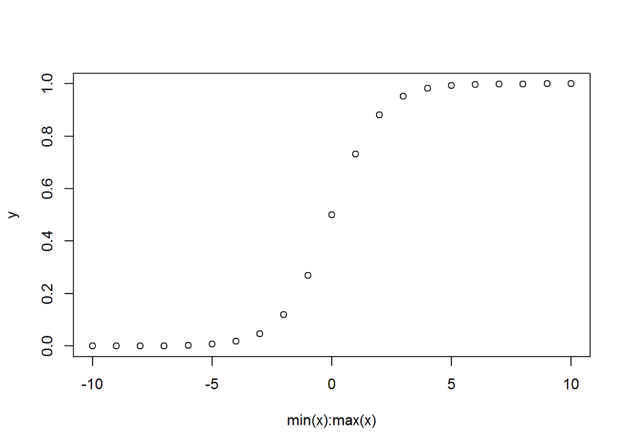

```
##  [1] 4.539787e-05 1.233946e-04 3.353501e-04 9.110512e-04 2.472623e-03
##  [6] 6.692851e-03 1.798621e-02 4.742587e-02 1.192029e-01 2.689414e-01
## [11] 5.000000e-01 7.310586e-01 8.807971e-01 9.525741e-01 9.820138e-01
## [16] 9.933071e-01 9.975274e-01 9.990889e-01 9.996646e-01 9.998766e-01
## [21] 9.999546e-01
```

```r
inv.logit(x)
```

# NYCFlights Model

Using the rectangular data that you created from the earlier assignment and following theexample from the text and class, create a model for arr_delay >= 22 minutes. Describe/Explain each of the steps and show all work.

KNIT YOUR DOCUMENT AS *HTML* AND SUBMIT IT AND THE `Rmd` file to your repository.

```r
library(dplyr)
library(readr)

# load the data
data <- read.csv("C:/Users/rtorres/Desktop/MachLearn/MyUser/CSX460/03-linear-regression/03-exercise-nycflights-model/NYCflights.csv", stringsAsFactors = FALSE)

# We want to model arrival delay as a binary variable.
# In other words, we consider a flight to be delayed if its arrival is 22 minutes delayed (y=1), otherwise it's considered on time (y=0).
data$y <- as.numeric(data$arr_delay >= 22)

# Tabulation of our dependent variable
table(data$y)
```

```
##
##      0      1
## 212872  52545
```

Borrowing from last weeks’ assigment, we concluded that the best liner model that minimized MSE–by the AIC measure–was:

arr_delay ~ dep_delay + month + air_time + distance + carrier + lat.dest + lon.dest

We now use that model, but changing the dependent variable with our newly created binary dependent variable

```r
OLS <- lm(y ~ dep_delay + month.flight + air_time + distance + carrier + lat.dest + lon.dest, data = data)

summary(OLS)
```

```
##
## Call:
## lm(formula = y ~ dep_delay + month.flight + air_time + distance +
##     carrier + lat.dest + lon.dest, data = data)
##
## Residuals:
##     Min      1Q  Median      3Q     Max
## -7.5291 -0.1453 -0.0814 -0.0122  1.1426
##
## Coefficients:
##                Estimate Std. Error t value Pr(>|t|)
## (Intercept)   1.410e-01  1.334e-02  10.575  < 2e-16 ***
## dep_delay     6.470e-03  1.473e-05 439.099  < 2e-16 ***
## month.flight  9.468e-04  1.713e-04   5.526 3.29e-08 ***
## air_time      5.631e-03  4.793e-05 117.480  < 2e-16 ***
## distance     -6.675e-04  7.920e-06 -84.284  < 2e-16 ***
## carrierAA    -2.675e-02  3.319e-03  -8.059 7.73e-16 ***
## carrierAS    -5.123e-02  1.286e-02  -3.985 6.75e-05 ***
## carrierB6     1.706e-02  3.100e-03   5.502 3.75e-08 ***
## carrierDL    -2.161e-02  3.088e-03  -7.000 2.57e-12 ***
## carrierEV     3.555e-02  2.886e-03  12.317  < 2e-16 ***
## carrierF9     2.305e-02  1.266e-02   1.821 0.068630 .
## carrierFL     5.338e-02  6.292e-03   8.483  < 2e-16 ***
## carrierHA     2.542e-03  2.001e-02   0.127 0.898910
## carrierMQ     4.549e-02  3.250e-03  13.999  < 2e-16 ***
## carrierOO     1.337e-01  6.323e-02   2.114 0.034523 *
## carrierUA    -1.423e-02  3.083e-03  -4.614 3.95e-06 ***
## carrierUS     8.984e-03  3.423e-03   2.625 0.008672 **
## carrierVX    -6.825e-02  5.683e-03 -12.009  < 2e-16 ***
## carrierWN    -4.054e-02  3.943e-03 -10.280  < 2e-16 ***
## carrierYV     5.539e-02  1.500e-02   3.694 0.000221 ***
## lat.dest     -2.550e-04  2.011e-04  -1.268 0.204835
## lon.dest      1.926e-03  2.675e-04   7.201 5.98e-13 ***
## ---
## Signif. codes:  0 '***' 0.001 '**' 0.01 '*' 0.05 '.' 0.1 ' ' 1
##
## Residual standard error: 0.2963 on 259469 degrees of freedom
##   (13297 observations deleted due to missingness)
## Multiple R-squared:  0.4486, Adjusted R-squared:  0.4486
## F-statistic: 1.005e+04 on 21 and 259469 DF,  p-value: < 2.2e-16
```

```r
# obtain predictions
pred.OLS <- predict(OLS)
summary(pred.OLS)
```

```
##     Min.  1st Qu.   Median     Mean  3rd Qu.     Max.
## -0.33580  0.06519  0.12160  0.19870  0.22390  8.52900
```

```r
# We see that OLS predicted values outside [0,1]. We now turn to our logit model:
LOGIT <- glm(y ~ dep_delay + month.flight + air_time + distance + carrier + lat.dest + lon.dest, data = data, family = binomial(link = "logit"))
summary(LOGIT)
```

```
##
## Call:
## glm(formula = y ~ dep_delay + month.flight + air_time + distance +
##     carrier + lat.dest + lon.dest, family = binomial(link = "logit"),
##     data = data)
##
## Deviance Residuals:
##     Min       1Q   Median       3Q      Max
## -3.0887  -0.3028  -0.1852  -0.0981   3.9466
##
## Coefficients:
##                Estimate Std. Error z value Pr(>|z|)
## (Intercept)  -3.2382835  0.2043032 -15.850  < 2e-16 ***
## dep_delay     0.1231387  0.0005957 206.701  < 2e-16 ***
## month.flight  0.0180392  0.0022841   7.898 2.84e-15 ***
## air_time      0.0873231  0.0007111 122.797  < 2e-16 ***
## distance     -0.0106577  0.0001217 -87.542  < 2e-16 ***
## carrierAA    -0.0409428  0.0521934  -0.784  0.43278
## carrierAS    -0.7674607  0.2365582  -3.244  0.00118 **
## carrierB6     0.4461771  0.0478281   9.329  < 2e-16 ***
## carrierDL     0.1992729  0.0484181   4.116 3.86e-05 ***
## carrierEV     0.3744192  0.0448388   8.350  < 2e-16 ***
## carrierF9     0.8070043  0.1493663   5.403 6.56e-08 ***
## carrierFL     1.1190251  0.0803364  13.929  < 2e-16 ***
## carrierHA     0.9897788  0.4342228   2.279  0.02264 *
## carrierMQ     0.9453691  0.0488584  19.349  < 2e-16 ***
## carrierOO     1.8427463  1.1907972   1.547  0.12175
## carrierUA    -0.0061254  0.0473867  -0.129  0.89715
## carrierUS     0.7140978  0.0531297  13.441  < 2e-16 ***
## carrierVX    -0.5118281  0.0902029  -5.674 1.39e-08 ***
## carrierWN    -0.5152495  0.0602898  -8.546  < 2e-16 ***
## carrierYV     0.6383882  0.2309699   2.764  0.00571 **
## lat.dest     -0.0088912  0.0031064  -2.862  0.00421 **
## lon.dest      0.0247519  0.0041563   5.955 2.60e-09 ***
## ---
## Signif. codes:  0 '***' 0.001 '**' 0.01 '*' 0.05 '.' 0.1 ' ' 1
##
## (Dispersion parameter for binomial family taken to be 1)
##
##     Null deviance: 258784  on 259490  degrees of freedom
## Residual deviance:  98323  on 259469  degrees of freedom
##   (13297 observations deleted due to missingness)
## AIC: 98367
##
## Number of Fisher Scoring iterations: 7
```

```r
pred.LOGIT <- predict(LOGIT, type = 'response')
```